# Understanding entropy and mutual information applied to the face orientation tuning

Tancy

5 February 2015

```r
library(plyr)
library(entropy)
library(ggplot2)
library(ggthemes)
library(gridExtra)
library(ks)
options(device='quartz')
```

1st step: z normalized of the timeseies from individual voxel

```r
RandomVox <- droplevels(subset(allData, Subj=='S02'& ROIs=='rOFA' & orient!=7 & orient!=6))
                              #& volume >= 1 & volume <=15
                              #& voxel %in% c(1,2,3, 7,8,25,45) )) # get 3 voxels info, remove blank baseline #,7,8,25,45
#head(RandomVox)
RandomVox_Zdata <- ddply(RandomVox, .(voxel), transform,  # get z normalized within a voxel across all selected orientations
                              zSigCh = scale(SignalChange))
#hist(RandomVox_Zdata$zSigCh) # plot histogram

# writeCSVname
#savefile <- "s01rFFA_MI_5orient.csv"
```

2nd step: plot hrf of each voxel

# kernel density distribution of ROI

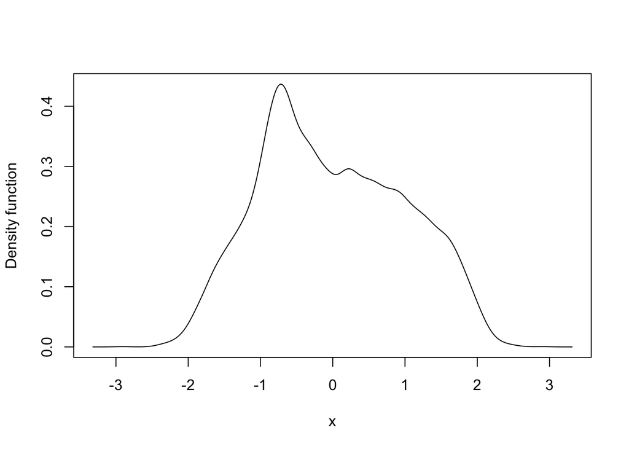

```r
kdeball <- kde(x=RandomVox_Zdata$zSigCh) # use kde to get bin width
plot(kdeball)
```

## Definition of entropy

Entropy was a measure introduced by Claude Shannon (1948,“A Mathematical Theory of Communication”) to measure the amount of uncertainty in a signal.

The entropy $H$ is defined as: $H(X)=-\sum\limits_{x=1}^np(x)\log_2p(x)$ $X$ is a discrete random variable and $f(x)$ is the value of its probability distribution at $x$ Because of $log_2$ entropy is measured in bits.

Entropy in BOLD responses $H(B)=-\sum\limits_{b\in B}p(b)\log_2p(b)$

3rd step: entropy of the ALL BOLD responses in each voxel 3.1 discretizing the continuous BOLD response into dscrete variable $B$ by dividing the range of responses into a set of equidistant bins $b$ nBins range is based on all voxels within a ROI 3.2 entropy of the BOLD responses in each voxel 4rd step: entropy of the each orientations of a voxel

```r
  ROI_range <- range(RandomVox_Zdata$zSigCh)
  kdebins <- ceiling(diff(ROI_range)/kdeball$h) # define bin from kde

computeVox_entropy <- function(Sig, numBins=kdebins, MImethod="ML"){
  BOLD_discreted <- discretize(Sig, numBins=numBins,r=ROI_range)
  HB_perVox <- entropy::entropy(BOLD_discreted, unit="log2", method = MImethod)
  return(HB_perVox)
  }

# H(B)
kdebins
```

```
## [1] 53
```

```r
fn <- function(x) computeVox_entropy(x)
HB <- ddply(RandomVox_Zdata, .(voxel), summarise, HB_perVox=fn(zSigCh)) # get entropys of per voxels
# H(B|theta_i)
HBtheta_i <- ddply(RandomVox_Zdata, .(voxel, orient), summarise, HB_perOrientVox=fn(zSigCh)) # get entropys of per orient in a voxel

# H(B|theta)

HBtheta <- ddply(HBtheta_i, .(voxel), summarise,
                  N = length(voxel),
                  meanHBtheta = mean(HB_perOrientVox))
```

The definition of Mutual information $H(X;Y) = -\sum\limits_{x\in X}\sum\limits_{y\in Y}p(x,y)\log_2p(x,y)/p(x)p(y) H(X;Y) = H(X) - H(X|Y) = H(Y) - H(Y|X) = H(X) + H(Y) - H(X,Y)$

$H(X), H(Y)$ is marginal entropy of X,Y; $H(X|Y)$ is conditional entropy of X given Y; $H(X,Y)$ is joint entroy of X and Y

Mutual information in BOLD responses $H(B;\Theta) = H(B) - H(B|\Theta) = H(B) + H(\Theta) - H(B,\Theta)$ $\Theta$ is the indvidual orientation that we presented

The definition of conditional entropy $H(Y|X) = -\sum\limits_{x\in X}p(x) H(Y|X = x) = -\sum\limits_{x\in X}p(x)\sum\limits_{y\in Y}p(y|x)\log_2p(y|x) = -\sum\limits_{x\in X}\sum\limits_{y\in Y}p(x,y)\log_2p(y|x)$

Conditonal Entropy of orientations in BOLD responses $H(B|\Theta) = -\sum\limits_{\theta\in \Theta}p(\theta)\sum\limits_{b\in B}p(b|\theta)\log_2p(b|\theta) = -\sum\limits_{b\in B}\sum\limits_{\theta\in \Theta}p(\theta,b)\log_2p(b|\theta)$ $\Theta$ is the indvidual orientation that we presented, computed condtional entropy $p(b|\theta)$, which measure the resp uncertainty given knowlegde of the stimulus orientation

```r
# MI = H(B)-H(B|theta)

MI_table <- merge(HB, HBtheta, by="voxel")
MI_table$MIvalue <- NA
MI_table$MIvalue <- MI_table$HB_perVox - MI_table$meanHBtheta

Coord  <- unique(RandomVox_Zdata[,c('voxel','x','y','z')]) # get voxel's coord
MI_table <- merge(MI_table, Coord, by="voxel")

mean(MI_table$MIvalue)
```

```
## [1] 0.9296042
```

```r
#write.csv(MI_table, file=savefile, row.names=FALSE)
```

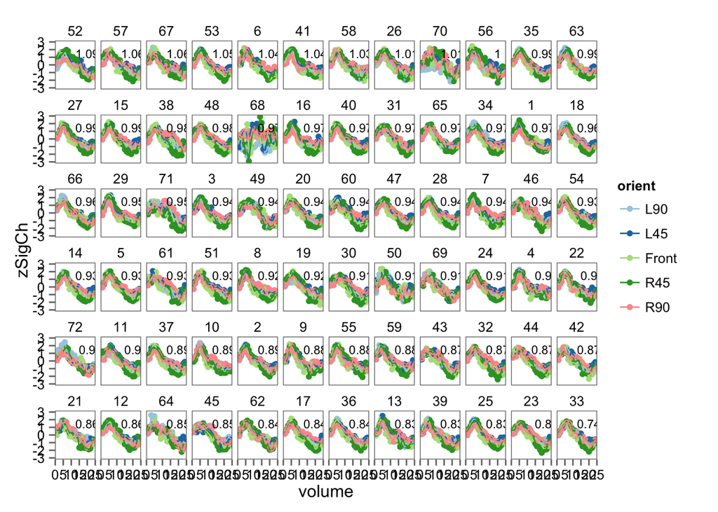

```r
meanMIvalues <- rep(MI_table$MIvalue, each =(nrow(RandomVox_Zdata)/length(unique(RandomVox_Zdata$voxel))))
RandomVox_ZdataMI <- cbind(RandomVox_Zdata,meanMIvalues)
RandomVox_ZdataMI$voxel <- as.factor(RandomVox_ZdataMI$voxel)

RandomVox_ZdataMI$voxel <- reorder(RandomVox_ZdataMI$voxel, -RandomVox_ZdataMI$meanMIvalues) # order voxel by MI values

miLabels <- ddply(RandomVox_ZdataMI, .(voxel), summarise, mi=mean(meanMIvalues)) # get mi label for each voxel
  dev.new()
  ggplot(data=RandomVox_ZdataMI, aes(x=volume, y=zSigCh)) +
  theme_few() +
  facet_wrap(~voxel, scales="fixed", nrow=6) +
  scale_color_brewer(palette='Paired',name="orient",
                       breaks=c("1", "2", "3","4","5"),
                       labels=c("L90","L45","Front","R45","R90")) +
  #geom_errorbar(aes(ymin=meanSigCh-se, ymax=meanSigCh+se), width=0.1) +
  geom_point(aes(colour = as.factor(orient)), size=2) +
  geom_line(aes(colour = as.factor(orient)), size=0.5)  +
  geom_text(data=miLabels, aes(x=20, y=1.5, label=paste(round(mi,2)), group=voxel), size=3)
```

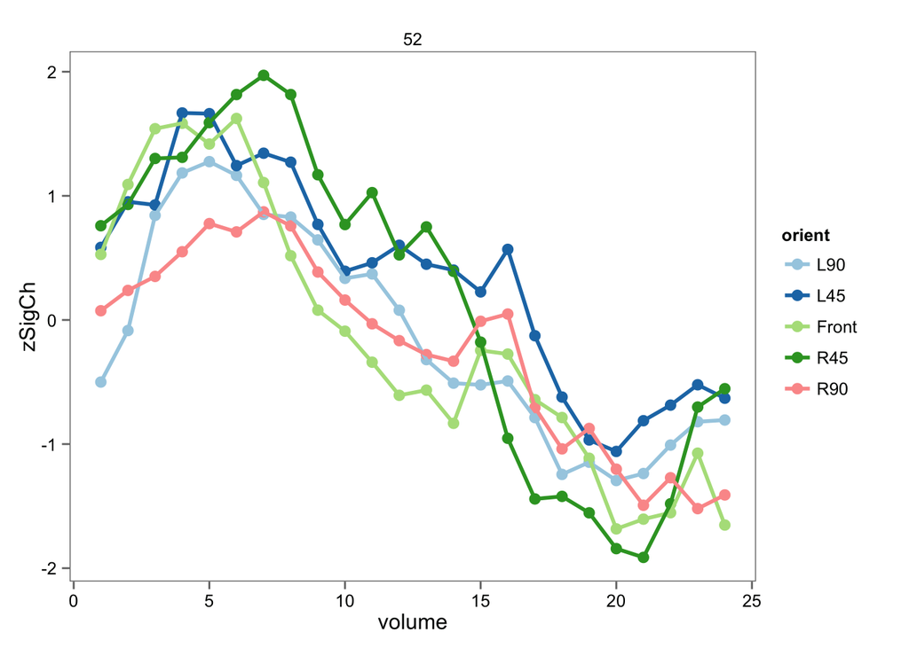

```r
SortMI<- MI_table[with(MI_table, order(-MIvalue,voxel)),] # sort voxel based on MI value from high to low
HighMIvoxel <- SortMI$voxel[1:1] # get highest MI voxels
LowMIvoxel <- SortMI$voxel[(NROW(SortMI)-1+1):NROW(SortMI)] # get lowest MI voxels
HighMIVox <- droplevels(subset(RandomVox_Zdata, voxel %in% c(HighMIvoxel)))
LowMIVox <- droplevels(subset(RandomVox_Zdata, voxel %in% c(LowMIvoxel)))

  dev.new()
  ggplot(HighMIVox, aes(x=volume, y=zSigCh, colour = as.factor(orient))) +
  theme_few() +
  facet_wrap(~voxel, scales="free_y", nrow=6) +
  scale_color_brewer(palette='Paired',name="orient",
                       breaks=c("1", "2", "3","4","5"),
                       labels=c("L90","L45","Front","R45","R90")) +
  #geom_errorbar(aes(ymin=meanSigCh-se, ymax=meanSigCh+se), width=0.1) +
  geom_point(size=3) +
  geom_line(size=1)
```

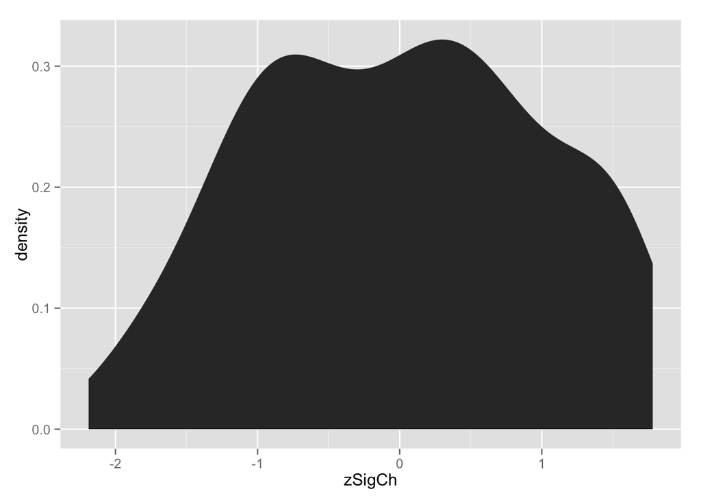

```r
vox1 <- subset(RandomVox_Zdata, voxel==33)

vox1$orient <- as.factor(vox1$orient)

ggplot(vox1, aes(x=zSigCh)) +
    stat_density()
```

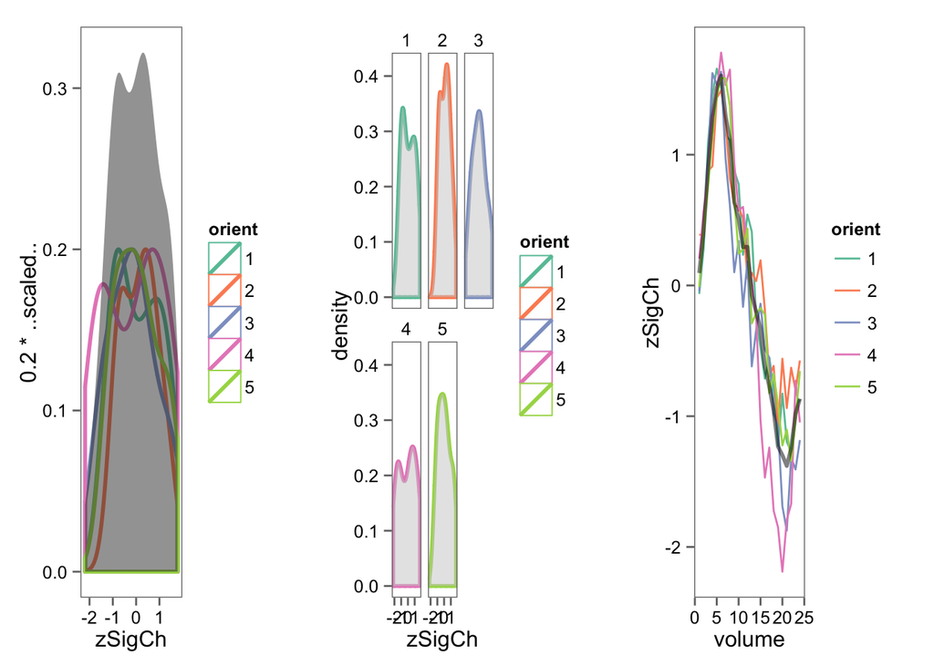

```r
dev.new()

#Density distribution of a voxel (merge all orients)
g1 <- ggplot(vox1, aes(x=zSigCh)) +
    theme_few() +
    scale_color_brewer(palette='Set2') +
    stat_density(aes(group=orient, color=orient, y=0.2*..scaled..), fill=NA, position='identity',bins=kdebins, size=1) +
    stat_density(fill='grey20', color=NA, size=2, alpha=0.5)

#Density distribution of each orient in a voxel
g2 <- ggplot(vox1, aes(x=zSigCh)) +
facet_wrap(~orient) +
 theme_few() +
 scale_color_brewer(palette='Set2') +
 stat_density(aes(group=orient, color=orient), fill=NA, position='identity', bins=kdebins, size=1) +
 stat_density(fill='grey80', color=NA, size=2, alpha=0.5)

#BOLD response of each orient in a voxel
g3 <- ggplot(vox1, aes(x=volume, y=zSigCh))  +
 theme_few() +
 scale_color_brewer(palette='Set2') +
 geom_line(aes(color=orient)) +
 geom_line(stat='summary', fun.y='mean', size=1, alpha=0.5)

grid.arrange(g1, g2, g3, nrow=1)
```

Since the experimental evaluation of these probabilities is made from a limited number of experimental observa- tions, the resulting information measures suffer from a limited sampling bias (Panzeri et al., 2007). Scrambling BOLD response and do bootstrapping

Bias_correct

```r
# HBScramble <- NaN
# for (temp in 1:3){
# # H(B)_scramble
#  browser()
#
#  #fn <- function(x) computeVox_entropy(x)
#  HBScramble[temp] <- ddply(RandomVox_Zdata, .(voxel), summarise, HB_perVox=computeVox_entropy(sample(zSigCh)))
#
#  ddply(RandomVox_Zdata, .(voxel), summarise, print(computeVox_entropy(sample(zSigCh))))
#
#  # H(B|theta_i)_scramble
#  #HBScramble_theta_i(temp) <- ddply(RandomVox_Zdata, .(voxel, orient), summarise, HB_perOrientVox=fn(sample#(zSigCh)))
#
# }
```

Reference http://info-theory.blogspot.jp/2005/01/understanding-mutual-information.html Gomez-Verdejjo(2012) Analysis of fMRI time series with mutual information http://thirdorderscientist.org/homoclinic-orbit/2013/8/25/all-i-really-need-for-data-analysis-i-learned-in-kindergarten-mdash-venn-shannon-and-independence

# to define the bin sizes

Legg(2007)Improving accurary and efficiency of registration by mutual information using Sturges’ histogram rule

# to adjust bias